```python
__author__ = "Kaylyn Vo"
__last_updated__ = '1/25/2021'
```

# **DATA SCIENCE FOR GOOD: PASSNYC**

Help PASSNYC Determine Which Schools Need Their Services The Most

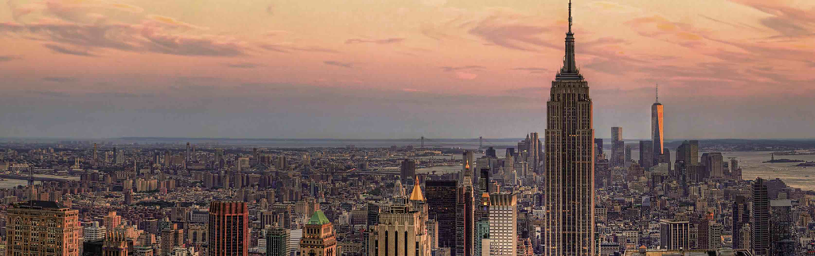

Credit: wallpapercave.com

- 1. Summary
  - 1.A. What is the SHSAT?
  - 1.B. Who is PASSNYC?
  - 1.C. Recommendations
- 2. Libraries
- 3. About the Data
- 4. Exploratory Data Analysis
  - 4.A. Data Cleaning
  - 4.B. Creating New Features
  - 4.C. Helper Functions
  - 4.D. Data Visualizations
    - 4.D.1 Share of African American and Hispanics Students of Total SHSAT testers
    - 4.D.2 Percentage of African American and Hispanics Students in Poverty
    - 4.D.3 Schools' Math and English State Performance
- 5. Analysis
  - 5.A. High ELA and Math Performance but Low Percentage of SHSAT Test Takers
  - 5.B. Low ELA and Math State Performance but High Percentage of SHSAT Test Takers
  - 5.C. Low ELA and Math State Performance and Low Percentage of SHSAT Test Takers
  - 5.D. High ELA and Math State Performance and High Percentage of SHSAT Test Takers

### 1. Summary

The Specialized High School Admission Test (SHSAT) is the sole criterion for admission to eight of the nine specialized high schools in New York city. Each year, the test is given to eighth and a limited number of nineth graders in October and November and students are informed of their results the following March. In 2019, about 30,000 students took the exam and just under 5,000 students received an admission offer to one of the elite high schools. The majority of students who received an offer were Asian with 51% or white with 29%. Four percent of the offers went to Black students and six percent of the offers went to Hispanic students. As New York City is engulfed in a debate over efforts to better integrate the city's specialized high schools, the elite high schools' population remain disproportionate with the city population. The city has tried number of other ways to diversify the schools. For example, more schools are now administering the SHSAT on campus during a school day. The city also created an initiative known as the Discovery program that offers admission to students from needy families who score just below the entrance exam cutoff. However, the number of Black and Hispanic students registering for the test and getting an offer remain stagnant.

#### 1.A. What is the SHSAT?

The SHSAT tests for grammar and ability in both English and mathematics. The score is determined by total number of correct answers is converted into a scaled score through a formula that the Department of Education does not release and it varies from year to year. This scaled score is between 200 and 800 and is used to determine a student's standing. The cut-off scores for each school depend on the number of open seats and how the performance of other candidates. The nine specialized high schools are:

- Bronx High School
- Brooklyn Latin School
- Brooklyn Technical High School
- High School of American Studies at Lehman College
- High School for Math, Science and Engineering at City College
- Queens High School for the Sciences at York College
- Staten Island Technical High School
- Stuyvesant High School
- Fiorello H. LaGuardia High School of Music & Art and Performing Arts.